# Risk Factor Analysis

## Outcome Variable

**Outcome Variable:** sstunted

## Predictor Variables

**Intervention Variable:** feducyrs

**Adjustment Set:**

- arm
- W_mage
- meducyrs
- hhwealth_quart
- W_mhtcm
- W_gagebrth
- W_birthwt
- W_birthlen
- single
- delta_W_mage
- delta_meducyrs
- delta_hhwealth_quart
- delta_W_mhtcm
- delta_W_gagebrth
- delta_W_birthwt
- delta_W_birthlen
- delta_single

## Stratifying Variables

The analysis was stratified on these variable(s):

- agecat
- studyid
- country

## Data Summary

| agecat | studyid | country | feducyrs | sstunted | n_cell | n |
| --- | --- | --- | --- | --- | --- | --- |
| Birth | ki0047075b-MAL-ED | BANGLADESH | High | 0 | 49 | 144 |
| Birth | ki0047075b-MAL-ED | BANGLADESH | High | 1 | 3 | 144 |
| Birth | ki0047075b-MAL-ED | BANGLADESH | Low | 0 | 37 | 144 |
| Birth | ki0047075b-MAL-ED | BANGLADESH | Low | 1 | 1 | 144 |
| Birth | ki0047075b-MAL-ED | BANGLADESH | Medium | 0 | 52 | 144 |
| Birth | ki0047075b-MAL-ED | BANGLADESH | Medium | 1 | 2 | 144 |
| Birth | ki0047075b-MAL-ED | INDIA | High | 0 | 38 | 123 |
| Birth | ki0047075b-MAL-ED | INDIA | High | 1 | 0 | 123 |
| Birth | ki0047075b-MAL-ED | INDIA | Low | 0 | 48 | 123 |
| Birth | ki0047075b-MAL-ED | INDIA | Low | 1 | 2 | 123 |
| Birth | ki0047075b-MAL-ED | INDIA | Medium | 0 | 34 | 123 |
| Birth | ki0047075b-MAL-ED | INDIA | Medium | 1 | 1 | 123 |
| Birth | ki0047075b-MAL-ED | NEPAL | High | 0 | 27 | 67 |
| Birth | ki0047075b-MAL-ED | NEPAL | High | 1 | 0 | 67 |
| Birth | ki0047075b-MAL-ED | NEPAL | Low | 0 | 18 | 67 |
| Birth | ki0047075b-MAL-ED | NEPAL | Low | 1 | 1 | 67 |
| Birth | ki0047075b-MAL-ED | NEPAL | Medium | 0 | 18 | 67 |
| Birth | ki0047075b-MAL-ED | NEPAL | Medium | 1 | 3 | 67 |
| Birth | ki0047075b-MAL-ED | PERU | High | 0 | 113 | 236 |
| Birth | ki0047075b-MAL-ED | PERU | High | 1 | 3 | 236 |
| Birth | ki0047075b-MAL-ED | PERU | Low | 0 | 63 | 236 |
| Birth | ki0047075b-MAL-ED | PERU | Low | 1 | 2 | 236 |
| Birth | ki0047075b-MAL-ED | PERU | Medium | 0 | 54 | 236 |
| Birth | ki0047075b-MAL-ED | PERU | Medium | 1 | 1 | 236 |
| Birth | ki0047075b-MAL-ED | SOUTH AFRICA | High | 0 | 35 | 91 |
| Birth | ki0047075b-MAL-ED | SOUTH AFRICA | High | 1 | 0 | 91 |
| Birth | ki0047075b-MAL-ED | SOUTH AFRICA | Low | 0 | 30 | 91 |
| Birth | ki0047075b-MAL-ED | SOUTH AFRICA | Low | 1 | 0 | 91 |
| Birth | ki0047075b-MAL-ED | SOUTH AFRICA | Medium | 0 | 26 | 91 |
| Birth | ki0047075b-MAL-ED | SOUTH AFRICA | Medium | 1 | 0 | 91 |

[output cut: 288 more lines]

The following strata were considered:

- agecat: 24 months, studyid: ki0047075b-MAL-ED, country: BANGLADESH
- agecat: 24 months, studyid: ki0047075b-MAL-ED, country: INDIA
- agecat: 24 months, studyid: ki0047075b-MAL-ED, country: NEPAL
- agecat: 24 months, studyid: ki0047075b-MAL-ED, country: PERU
- agecat: 24 months, studyid: ki0047075b-MAL-ED, country: SOUTH AFRICA
- agecat: 24 months, studyid: ki0047075b-MAL-ED, country: TANZANIA, UNITED REPUBLIC OF
- agecat: 24 months, studyid: ki1017093b-PROVIDE, country: BANGLADESH
- agecat: 24 months, studyid: ki1017093c-NIH-Crypto, country: BANGLADESH
- agecat: 24 months, studyid: ki1066203-TanzaniaChild2, country: TANZANIA, UNITED REPUBLIC OF
- agecat: 24 months, studyid: ki1113344-GMS-Nepal, country: NEPAL
- agecat: 24 months, studyid: ki1119695-PROBIT, country: BELARUS
- agecat: 24 months, studyid: ki1126311-ZVITAMBO, country: ZIMBABWE
- agecat: 24 months, studyid: ki1135781-COHORTS, country: GUATEMALA
- agecat: 24 months, studyid: ki1135781-COHORTS, country: INDIA
- agecat: 24 months, studyid: ki1135781-COHORTS, country: PHILIPPINES
- agecat: 24 months, studyid: ki1148112-LCNI-5, country: MALAWI
- agecat: 24 months, studyid: kiGH5241-JiVitA-3, country: BANGLADESH
- agecat: 24 months, studyid: kiGH5241-JiVitA-4, country: BANGLADESH
- agecat: 6 months, studyid: ki0047075b-MAL-ED, country: BANGLADESH
- agecat: 6 months, studyid: ki0047075b-MAL-ED, country: INDIA
- agecat: 6 months, studyid: ki0047075b-MAL-ED, country: NEPAL
- agecat: 6 months, studyid: ki0047075b-MAL-ED, country: PERU
- agecat: 6 months, studyid: ki0047075b-MAL-ED, country: SOUTH AFRICA
- agecat: 6 months, studyid: ki0047075b-MAL-ED, country: TANZANIA, UNITED REPUBLIC OF
- agecat: 6 months, studyid: ki1000304b-SAS-CompFeed, country: INDIA
- agecat: 6 months, studyid: ki1000304b-SAS-FoodSuppl, country: INDIA
- agecat: 6 months, studyid: ki1017093b-PROVIDE, country: BANGLADESH
- agecat: 6 months, studyid: ki1017093c-NIH-Crypto, country: BANGLADESH
- agecat: 6 months, studyid: ki1066203-TanzaniaChild2, country: TANZANIA, UNITED REPUBLIC OF
- agecat: 6 months, studyid: ki1113344-GMS-Nepal, country: NEPAL
- agecat: 6 months, studyid: ki1119695-PROBIT, country: BELARUS
- agecat: 6 months, studyid: ki1126311-ZVITAMBO, country: ZIMBABWE
- agecat: 6 months, studyid: ki1135781-COHORTS, country: GUATEMALA
- agecat: 6 months, studyid: ki1135781-COHORTS, country: INDIA
- agecat: 6 months, studyid: ki1135781-COHORTS, country: PHILIPPINES
- agecat: 6 months, studyid: ki1148112-LCNI-5, country: MALAWI
- agecat: 6 months, studyid: kiGH5241-JiVitA-3, country: BANGLADESH
- agecat: 6 months, studyid: kiGH5241-JiVitA-4, country: BANGLADESH
- agecat: Birth, studyid: ki0047075b-MAL-ED, country: BANGLADESH
- agecat: Birth, studyid: ki0047075b-MAL-ED, country: INDIA
- agecat: Birth, studyid: ki0047075b-MAL-ED, country: NEPAL
- agecat: Birth, studyid: ki0047075b-MAL-ED, country: PERU
- agecat: Birth, studyid: ki0047075b-MAL-ED, country: SOUTH AFRICA
- agecat: Birth, studyid: ki0047075b-MAL-ED, country: TANZANIA, UNITED REPUBLIC OF
- agecat: Birth, studyid: ki1000304b-SAS-CompFeed, country: INDIA
- agecat: Birth, studyid: ki1017093c-NIH-Crypto, country: BANGLADESH
- agecat: Birth, studyid: ki1119695-PROBIT, country: BELARUS
- agecat: Birth, studyid: ki1126311-ZVITAMBO, country: ZIMBABWE
- agecat: Birth, studyid: ki1135781-COHORTS, country: GUATEMALA
- agecat: Birth, studyid: ki1135781-COHORTS, country: INDIA
- agecat: Birth, studyid: ki1135781-COHORTS, country: PHILIPPINES
- agecat: Birth, studyid: kiGH5241-JiVitA-3, country: BANGLADESH
- agecat: Birth, studyid: kiGH5241-JiVitA-4, country: BANGLADESH

### Dropped Strata

Some strata were dropped due to rare outcomes:

- agecat: Birth, studyid: ki0047075b-MAL-ED, country: BANGLADESH
- agecat: Birth, studyid: ki0047075b-MAL-ED, country: INDIA
- agecat: Birth, studyid: ki0047075b-MAL-ED, country: NEPAL
- agecat: Birth, studyid: ki0047075b-MAL-ED, country: PERU
- agecat: Birth, studyid: ki0047075b-MAL-ED, country: SOUTH AFRICA
- agecat: Birth, studyid: ki0047075b-MAL-ED, country: TANZANIA, UNITED REPUBLIC OF
- agecat: Birth, studyid: ki1000304b-SAS-CompFeed, country: INDIA
- agecat: Birth, studyid: ki1017093c-NIH-Crypto, country: BANGLADESH
- agecat: Birth, studyid: ki1119695-PROBIT, country: BELARUS
- agecat: Birth, studyid: ki1135781-COHORTS, country: GUATEMALA
- agecat: 6 months, studyid: ki0047075b-MAL-ED, country: BANGLADESH
- agecat: 6 months, studyid: ki0047075b-MAL-ED, country: INDIA
- agecat: 6 months, studyid: ki0047075b-MAL-ED, country: NEPAL
- agecat: 6 months, studyid: ki0047075b-MAL-ED, country: PERU
- agecat: 6 months, studyid: ki0047075b-MAL-ED, country: SOUTH AFRICA
- agecat: 6 months, studyid: ki0047075b-MAL-ED, country: TANZANIA, UNITED REPUBLIC OF
- agecat: 6 months, studyid: ki1017093b-PROVIDE, country: BANGLADESH
- agecat: 6 months, studyid: ki1113344-GMS-Nepal, country: NEPAL
- agecat: 24 months, studyid: ki0047075b-MAL-ED, country: BANGLADESH
- agecat: 24 months, studyid: ki0047075b-MAL-ED, country: INDIA
- agecat: 24 months, studyid: ki0047075b-MAL-ED, country: NEPAL
- agecat: 24 months, studyid: ki0047075b-MAL-ED, country: PERU
- agecat: 24 months, studyid: ki0047075b-MAL-ED, country: SOUTH AFRICA
- agecat: 24 months, studyid: ki1066203-TanzaniaChild2, country: TANZANIA, UNITED REPUBLIC OF
- agecat: 24 months, studyid: ki1126311-ZVITAMBO, country: ZIMBABWE

## Methods Detail

We’re interested in the causal parameters $E[Y_a]$ for all values of $a \in \mathcal{A}$. These parameters represent the mean outcome if, possibly contrary to fact, we intervened to set all units to have $A=a$. Under the randomization and positivity assumptions, these are identified by the statistical parameters $\psi_a=E_W[E_{Y|A,W}(Y|A=a,W)]$. In addition, we’re interested in the mean of $Y$, $E[Y]$ under no intervention (the observed mean). We will estimate these parameters by using SuperLearner to fit the relevant likelihood factors – $E_{Y|A,W}(Y|A=a,W)$ and $p(A=a|W)$, and then updating our likelihood fit using a joint TMLE.

For unadjusted analyses ($W=\{\}$), initial likelihoods were estimated using Lrnr_glm to estimate the simple $E(Y|A)$ and Lrnr_mean to estimate $p(A)$. For adjusted analyses, a small library containing Lrnr_glmnet, Lrnr_xgboost, and Lrnr_mean was used.

Having estimated these parameters, we will then use the delta method to estimate relative risks and attributable risks relative to a prespecified baseline level of $A$.

# Results Detail

## Results Plots

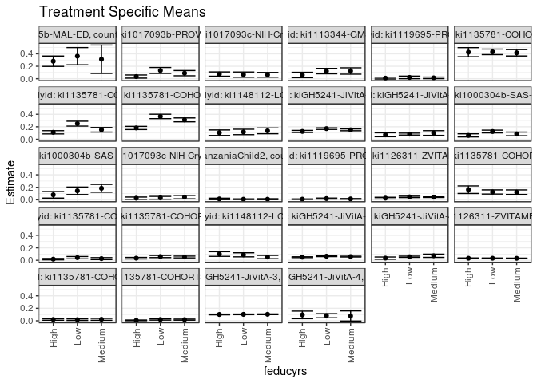

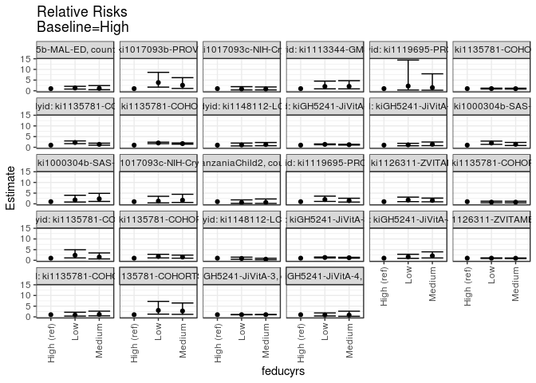

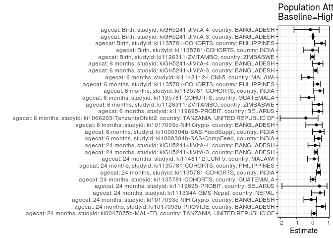

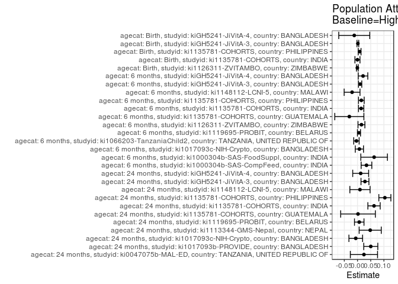

## Results Table

### Parameter: TSM

| agecat | studyid | country | intervention_level | baseline_level | estimate | ci_lower | ci_upper |
| --- | --- | --- | --- | --- | --- | --- | --- |
| Birth | ki1126311-ZVITAMBO | ZIMBABWE | High | NA | 0.0324342 | 0.0279050 | 0.0369635 |
| Birth | ki1126311-ZVITAMBO | ZIMBABWE | Low | NA | 0.0325077 | 0.0286137 | 0.0364018 |
| Birth | ki1126311-ZVITAMBO | ZIMBABWE | Medium | NA | 0.0314444 | 0.0284078 | 0.0344810 |
| Birth | ki1135781-COHORTS | INDIA | High | NA | 0.0208729 | 0.0086629 | 0.0330828 |
| Birth | ki1135781-COHORTS | INDIA | Low | NA | 0.0182232 | 0.0057064 | 0.0307401 |
| Birth | ki1135781-COHORTS | INDIA | Medium | NA | 0.0231959 | 0.0082128 | 0.0381790 |
| Birth | ki1135781-COHORTS | PHILIPPINES | High | NA | 0.0068160 | 0.0017831 | 0.0118489 |
| Birth | ki1135781-COHORTS | PHILIPPINES | Low | NA | 0.0205562 | 0.0108839 | 0.0302286 |
| Birth | ki1135781-COHORTS | PHILIPPINES | Medium | NA | 0.0186457 | 0.0103388 | 0.0269526 |
| Birth | kiGH5241-JiVitA-3 | BANGLADESH | High | NA | 0.1011432 | 0.0953166 | 0.1069699 |
| Birth | kiGH5241-JiVitA-3 | BANGLADESH | Low | NA | 0.1028205 | 0.0976991 | 0.1079418 |
| Birth | kiGH5241-JiVitA-3 | BANGLADESH | Medium | NA | 0.1038072 | 0.0985370 | 0.1090775 |
| Birth | kiGH5241-JiVitA-4 | BANGLADESH | High | NA | 0.0943396 | 0.0339904 | 0.1546888 |
| Birth | kiGH5241-JiVitA-4 | BANGLADESH | Low | NA | 0.0810811 | 0.0483586 | 0.1138036 |
| Birth | kiGH5241-JiVitA-4 | BANGLADESH | Medium | NA | 0.0769231 | -0.0043285 | 0.1581746 |
| 6 months | ki1000304b-SAS-CompFeed | INDIA | High | NA | 0.0620385 | 0.0368775 | 0.0871995 |
| 6 months | ki1000304b-SAS-CompFeed | INDIA | Low | NA | 0.1238353 | 0.1015698 | 0.1461008 |
| 6 months | ki1000304b-SAS-CompFeed | INDIA | Medium | NA | 0.0856959 | 0.0565446 | 0.1148472 |
| 6 months | ki1000304b-SAS-FoodSuppl | INDIA | High | NA | 0.0792079 | 0.0264698 | 0.1319460 |
| 6 months | ki1000304b-SAS-FoodSuppl | INDIA | Low | NA | 0.1439394 | 0.0839775 | 0.2039013 |
| 6 months | ki1000304b-SAS-FoodSuppl | INDIA | Medium | NA | 0.1836735 | 0.1209952 | 0.2463517 |
| 6 months | ki1017093c-NIH-Crypto | BANGLADESH | High | NA | 0.0250896 | 0.0067251 | 0.0434541 |
| 6 months | ki1017093c-NIH-Crypto | BANGLADESH | Low | NA | 0.0313901 | 0.0084883 | 0.0542920 |
| 6 months | ki1017093c-NIH-Crypto | BANGLADESH | Medium | NA | 0.0422535 | 0.0152190 | 0.0692881 |
| 6 months | ki1066203-TanzaniaChild2 | TANZANIA, UNITED REPUBLIC OF | High | NA | 0.0134771 | 0.0017411 | 0.0252131 |
| 6 months | ki1066203-TanzaniaChild2 | TANZANIA, UNITED REPUBLIC OF | Low | NA | 0.0083102 | 0.0029023 | 0.0137182 |
| 6 months | ki1066203-TanzaniaChild2 | TANZANIA, UNITED REPUBLIC OF | Medium | NA | 0.0088652 | 0.0011273 | 0.0166032 |
| 6 months | ki1119695-PROBIT | BELARUS | High | NA | 0.0092830 | 0.0051447 | 0.0134213 |
| 6 months | ki1119695-PROBIT | BELARUS | Low | NA | 0.0185437 | 0.0104194 | 0.0266681 |
| 6 months | ki1119695-PROBIT | BELARUS | Medium | NA | 0.0135395 | 0.0082888 | 0.0187903 |

[output cut: 54 more lines]

### Parameter: E(Y)

| agecat | studyid | country | intervention_level | baseline_level | estimate | ci_lower | ci_upper |
| --- | --- | --- | --- | --- | --- | --- | --- |
| Birth | ki1126311-ZVITAMBO | ZIMBABWE | NA | NA | 0.0317979 | 0.0288336 | 0.0347622 |
| Birth | ki1135781-COHORTS | INDIA | NA | NA | 0.0206795 | 0.0130966 | 0.0282623 |
| Birth | ki1135781-COHORTS | PHILIPPINES | NA | NA | 0.0149669 | 0.0105263 | 0.0194076 |
| Birth | kiGH5241-JiVitA-3 | BANGLADESH | NA | NA | 0.1024757 | 0.0976627 | 0.1072888 |
| Birth | kiGH5241-JiVitA-4 | BANGLADESH | NA | NA | 0.0820399 | 0.0540196 | 0.1100602 |
| 6 months | ki1000304b-SAS-CompFeed | INDIA | NA | NA | 0.0960240 | 0.0777684 | 0.1142796 |
| 6 months | ki1000304b-SAS-FoodSuppl | INDIA | NA | NA | 0.1421053 | 0.1069532 | 0.1772573 |
| 6 months | ki1017093c-NIH-Crypto | BANGLADESH | NA | NA | 0.0321678 | 0.0192256 | 0.0451101 |
| 6 months | ki1066203-TanzaniaChild2 | TANZANIA, UNITED REPUBLIC OF | NA | NA | 0.0094153 | 0.0052007 | 0.0136299 |
| 6 months | ki1119695-PROBIT | BELARUS | NA | NA | 0.0148577 | 0.0096205 | 0.0200949 |
| 6 months | ki1126311-ZVITAMBO | ZIMBABWE | NA | NA | 0.0409277 | 0.0366029 | 0.0452524 |
| 6 months | ki1135781-COHORTS | GUATEMALA | NA | NA | 0.1305310 | 0.1085580 | 0.1525039 |
| 6 months | ki1135781-COHORTS | INDIA | NA | NA | 0.0317690 | 0.0225290 | 0.0410089 |
| 6 months | ki1135781-COHORTS | PHILIPPINES | NA | NA | 0.0483619 | 0.0400565 | 0.0566674 |
| 6 months | ki1148112-LCNI-5 | MALAWI | NA | NA | 0.0800493 | 0.0613726 | 0.0987259 |
| 6 months | kiGH5241-JiVitA-3 | BANGLADESH | NA | NA | 0.0593851 | 0.0553716 | 0.0633986 |
| 6 months | kiGH5241-JiVitA-4 | BANGLADESH | NA | NA | 0.0557174 | 0.0473621 | 0.0640727 |
| 24 months | ki0047075b-MAL-ED | TANZANIA, UNITED REPUBLIC OF | NA | NA | 0.3050847 | 0.2370598 | 0.3731096 |
| 24 months | ki1017093b-PROVIDE | BANGLADESH | NA | NA | 0.0849220 | 0.0621566 | 0.1076874 |
| 24 months | ki1017093c-NIH-Crypto | BANGLADESH | NA | NA | 0.0680934 | 0.0462948 | 0.0898920 |
| 24 months | ki1113344-GMS-Nepal | NEPAL | NA | NA | 0.1084337 | 0.0810981 | 0.1357694 |
| 24 months | ki1119695-PROBIT | BELARUS | NA | NA | 0.0161002 | 0.0033894 | 0.0288110 |
| 24 months | ki1135781-COHORTS | GUATEMALA | NA | NA | 0.4271357 | 0.3963844 | 0.4578870 |
| 24 months | ki1135781-COHORTS | INDIA | NA | NA | 0.1739130 | 0.1539078 | 0.1939183 |
| 24 months | ki1135781-COHORTS | PHILIPPINES | NA | NA | 0.2843561 | 0.2659721 | 0.3027401 |
| 24 months | ki1148112-LCNI-5 | MALAWI | NA | NA | 0.1138354 | 0.0877614 | 0.1399093 |
| 24 months | kiGH5241-JiVitA-3 | BANGLADESH | NA | NA | 0.1535030 | 0.1445839 | 0.1624220 |
| 24 months | kiGH5241-JiVitA-4 | BANGLADESH | NA | NA | 0.0838901 | 0.0710207 | 0.0967596 |

### Parameter: RR

| agecat | studyid | country | intervention_level | baseline_level | estimate | ci_lower | ci_upper |
| --- | --- | --- | --- | --- | --- | --- | --- |
| Birth | ki1126311-ZVITAMBO | ZIMBABWE | High | High | 1.0000000 | 1.0000000 | 1.0000000 |
| Birth | ki1126311-ZVITAMBO | ZIMBABWE | Low | High | 1.0022655 | 0.8729566 | 1.1507285 |
| Birth | ki1126311-ZVITAMBO | ZIMBABWE | Medium | High | 0.9694814 | 0.8612873 | 1.0912668 |
| Birth | ki1135781-COHORTS | INDIA | High | High | 1.0000000 | 1.0000000 | 1.0000000 |
| Birth | ki1135781-COHORTS | INDIA | Low | High | 0.8730586 | 0.3541786 | 2.1521100 |
| Birth | ki1135781-COHORTS | INDIA | Medium | High | 1.1112933 | 0.4649040 | 2.6564042 |
| Birth | ki1135781-COHORTS | PHILIPPINES | High | High | 1.0000000 | 1.0000000 | 1.0000000 |
| Birth | ki1135781-COHORTS | PHILIPPINES | Low | High | 3.0158921 | 1.2564898 | 7.2389007 |
| Birth | ki1135781-COHORTS | PHILIPPINES | Medium | High | 2.7355950 | 1.1548408 | 6.4800967 |
| Birth | kiGH5241-JiVitA-3 | BANGLADESH | High | High | 1.0000000 | 1.0000000 | 1.0000000 |
| Birth | kiGH5241-JiVitA-3 | BANGLADESH | Low | High | 1.0165829 | 0.9749653 | 1.0599770 |
| Birth | kiGH5241-JiVitA-3 | BANGLADESH | Medium | High | 1.0263387 | 0.9829796 | 1.0716104 |
| Birth | kiGH5241-JiVitA-4 | BANGLADESH | High | High | 1.0000000 | 1.0000000 | 1.0000000 |
| Birth | kiGH5241-JiVitA-4 | BANGLADESH | Low | High | 0.8594595 | 0.4024736 | 1.8353269 |
| Birth | kiGH5241-JiVitA-4 | BANGLADESH | Medium | High | 0.8153846 | 0.2520576 | 2.6376993 |
| 6 months | ki1000304b-SAS-CompFeed | INDIA | High | High | 1.0000000 | 1.0000000 | 1.0000000 |
| 6 months | ki1000304b-SAS-CompFeed | INDIA | Low | High | 1.9961049 | 1.3752213 | 2.8973045 |
| 6 months | ki1000304b-SAS-CompFeed | INDIA | Medium | High | 1.3813347 | 0.8388039 | 2.2747697 |
| 6 months | ki1000304b-SAS-FoodSuppl | INDIA | High | High | 1.0000000 | 1.0000000 | 1.0000000 |
| 6 months | ki1000304b-SAS-FoodSuppl | INDIA | Low | High | 1.8172348 | 0.8285460 | 3.9857080 |
| 6 months | ki1000304b-SAS-FoodSuppl | INDIA | Medium | High | 2.3188776 | 1.0973616 | 4.9001104 |
| 6 months | ki1017093c-NIH-Crypto | BANGLADESH | High | High | 1.0000000 | 1.0000000 | 1.0000000 |
| 6 months | ki1017093c-NIH-Crypto | BANGLADESH | Low | High | 1.2511211 | 0.4451121 | 3.5166512 |
| 6 months | ki1017093c-NIH-Crypto | BANGLADESH | Medium | High | 1.6841046 | 0.6370276 | 4.4522534 |
| 6 months | ki1066203-TanzaniaChild2 | TANZANIA, UNITED REPUBLIC OF | High | High | 1.0000000 | 1.0000000 | 1.0000000 |
| 6 months | ki1066203-TanzaniaChild2 | TANZANIA, UNITED REPUBLIC OF | Low | High | 0.6166205 | 0.2079183 | 1.8287029 |
| 6 months | ki1066203-TanzaniaChild2 | TANZANIA, UNITED REPUBLIC OF | Medium | High | 0.6578014 | 0.1917037 | 2.2571436 |
| 6 months | ki1119695-PROBIT | BELARUS | High | High | 1.0000000 | 1.0000000 | 1.0000000 |
| 6 months | ki1119695-PROBIT | BELARUS | Low | High | 1.9976054 | 1.1105160 | 3.5933090 |
| 6 months | ki1119695-PROBIT | BELARUS | Medium | High | 1.4585290 | 0.8188739 | 2.5978443 |

[output cut: 54 more lines]

### Parameter: PAR

| agecat | studyid | country | intervention_level | baseline_level | estimate | ci_lower | ci_upper |
| --- | --- | --- | --- | --- | --- | --- | --- |
| Birth | ki1126311-ZVITAMBO | ZIMBABWE | High | NA | -0.0006363 | -0.0040688 | 0.0027962 |
| Birth | ki1135781-COHORTS | INDIA | High | NA | -0.0001934 | -0.0097082 | 0.0093214 |
| Birth | ki1135781-COHORTS | PHILIPPINES | High | NA | 0.0081510 | 0.0029606 | 0.0133414 |
| Birth | kiGH5241-JiVitA-3 | BANGLADESH | High | NA | 0.0013325 | -0.0019955 | 0.0046605 |
| Birth | kiGH5241-JiVitA-4 | BANGLADESH | High | NA | -0.0122997 | -0.0710565 | 0.0464571 |
| 6 months | ki1000304b-SAS-CompFeed | INDIA | High | NA | 0.0339855 | 0.0137790 | 0.0541921 |
| 6 months | ki1000304b-SAS-FoodSuppl | INDIA | High | NA | 0.0628973 | 0.0125139 | 0.1132808 |
| 6 months | ki1017093c-NIH-Crypto | BANGLADESH | High | NA | 0.0070782 | -0.0084639 | 0.0226203 |
| 6 months | ki1066203-TanzaniaChild2 | TANZANIA, UNITED REPUBLIC OF | High | NA | -0.0040618 | -0.0143016 | 0.0061780 |
| 6 months | ki1119695-PROBIT | BELARUS | High | NA | 0.0055747 | -0.0003114 | 0.0114608 |
| 6 months | ki1126311-ZVITAMBO | ZIMBABWE | High | NA | 0.0149251 | 0.0018902 | 0.0279599 |
| 6 months | ki1135781-COHORTS | GUATEMALA | High | NA | -0.0309482 | -0.0860687 | 0.0241722 |
| 6 months | ki1135781-COHORTS | INDIA | High | NA | 0.0138377 | 0.0037571 | 0.0239183 |
| 6 months | ki1135781-COHORTS | PHILIPPINES | High | NA | 0.0145274 | 0.0038000 | 0.0252549 |
| 6 months | ki1148112-LCNI-5 | MALAWI | High | NA | -0.0205745 | -0.0505881 | 0.0094392 |
| 6 months | kiGH5241-JiVitA-3 | BANGLADESH | High | NA | 0.0099352 | 0.0037000 | 0.0161705 |
| 6 months | kiGH5241-JiVitA-4 | BANGLADESH | High | NA | 0.0209526 | 0.0029892 | 0.0389160 |
| 24 months | ki0047075b-MAL-ED | TANZANIA, UNITED REPUBLIC OF | High | NA | 0.0243830 | -0.0271520 | 0.0759180 |
| 24 months | ki1017093b-PROVIDE | BANGLADESH | High | NA | 0.0502685 | 0.0236351 | 0.0769019 |
| 24 months | ki1017093c-NIH-Crypto | BANGLADESH | High | NA | -0.0066733 | -0.0325420 | 0.0191955 |
| 24 months | ki1113344-GMS-Nepal | NEPAL | High | NA | 0.0480889 | 0.0062290 | 0.0899488 |
| 24 months | ki1119695-PROBIT | BELARUS | High | NA | 0.0065308 | -0.0114833 | 0.0245449 |
| 24 months | ki1135781-COHORTS | GUATEMALA | High | NA | 0.0019185 | -0.0637854 | 0.0676224 |
| 24 months | ki1135781-COHORTS | INDIA | High | NA | 0.0625869 | 0.0392355 | 0.0859382 |
| 24 months | ki1135781-COHORTS | PHILIPPINES | High | NA | 0.1035892 | 0.0808100 | 0.1263685 |
| 24 months | ki1148112-LCNI-5 | MALAWI | High | NA | 0.0092953 | -0.0290101 | 0.0476007 |
| 24 months | kiGH5241-JiVitA-3 | BANGLADESH | High | NA | 0.0282286 | 0.0132064 | 0.0432508 |
| 24 months | kiGH5241-JiVitA-4 | BANGLADESH | High | NA | 0.0120440 | -0.0181184 | 0.0422064 |

### Parameter: PAF

| agecat | studyid | country | intervention_level | baseline_level | estimate | ci_lower | ci_upper |
| --- | --- | --- | --- | --- | --- | --- | --- |
| Birth | ki1126311-ZVITAMBO | ZIMBABWE | High | NA | -0.0200111 | -0.1339006 | 0.0824394 |
| Birth | ki1135781-COHORTS | INDIA | High | NA | -0.0093521 | -0.5922383 | 0.3601512 |
| Birth | ki1135781-COHORTS | PHILIPPINES | High | NA | 0.5445982 | 0.1054980 | 0.7681494 |
| Birth | kiGH5241-JiVitA-3 | BANGLADESH | High | NA | 0.0130031 | -0.0200134 | 0.0449508 |
| Birth | kiGH5241-JiVitA-4 | BANGLADESH | High | NA | -0.1499235 | -1.1642819 | 0.3890241 |
| 6 months | ki1000304b-SAS-CompFeed | INDIA | High | NA | 0.3539275 | 0.1039877 | 0.5341473 |
| 6 months | ki1000304b-SAS-FoodSuppl | INDIA | High | NA | 0.4426109 | -0.0267209 | 0.6974031 |
| 6 months | ki1017093c-NIH-Crypto | BANGLADESH | High | NA | 0.2200405 | -0.4347783 | 0.5760064 |
| 6 months | ki1066203-TanzaniaChild2 | TANZANIA, UNITED REPUBLIC OF | High | NA | -0.4314087 | -2.0243888 | 0.3225306 |
| 6 months | ki1119695-PROBIT | BELARUS | High | NA | 0.3752057 | -0.0312952 | 0.6214780 |
| 6 months | ki1126311-ZVITAMBO | ZIMBABWE | High | NA | 0.3646695 | -0.0449924 | 0.6137342 |
| 6 months | ki1135781-COHORTS | GUATEMALA | High | NA | -0.2370950 | -0.7387570 | 0.1198287 |
| 6 months | ki1135781-COHORTS | INDIA | High | NA | 0.4355723 | 0.0521351 | 0.6638987 |
| 6 months | ki1135781-COHORTS | PHILIPPINES | High | NA | 0.3003897 | 0.0475392 | 0.4861158 |
| 6 months | ki1148112-LCNI-5 | MALAWI | High | NA | -0.2570227 | -0.6885723 | 0.0642355 |
| 6 months | kiGH5241-JiVitA-3 | BANGLADESH | High | NA | 0.1673020 | 0.0562930 | 0.2652530 |
| 6 months | kiGH5241-JiVitA-4 | BANGLADESH | High | NA | 0.3760514 | -0.0335369 | 0.6233208 |
| 24 months | ki0047075b-MAL-ED | TANZANIA, UNITED REPUBLIC OF | High | NA | 0.0799220 | -0.1052818 | 0.2340926 |
| 24 months | ki1017093b-PROVIDE | BANGLADESH | High | NA | 0.5919378 | 0.2013461 | 0.7915057 |
| 24 months | ki1017093c-NIH-Crypto | BANGLADESH | High | NA | -0.0980016 | -0.5521926 | 0.2232874 |
| 24 months | ki1113344-GMS-Nepal | NEPAL | High | NA | 0.4434866 | -0.0854430 | 0.7146721 |
| 24 months | ki1119695-PROBIT | BELARUS | High | NA | 0.4056353 | -1.9090987 | 0.8785640 |
| 24 months | ki1135781-COHORTS | GUATEMALA | High | NA | 0.0044915 | -0.1618603 | 0.1470255 |
| 24 months | ki1135781-COHORTS | INDIA | High | NA | 0.3598744 | 0.2167990 | 0.4768128 |
| 24 months | ki1135781-COHORTS | PHILIPPINES | High | NA | 0.3642941 | 0.2816735 | 0.4374118 |
| 24 months | ki1148112-LCNI-5 | MALAWI | High | NA | 0.0816554 | -0.3230603 | 0.3625712 |
| 24 months | kiGH5241-JiVitA-3 | BANGLADESH | High | NA | 0.1838963 | 0.0806864 | 0.2755190 |
| 24 months | kiGH5241-JiVitA-4 | BANGLADESH | High | NA | 0.1435690 | -0.2998118 | 0.4357076 |